- ## last review :

  I decided to rest and start over and change the data set because of the last review , I would like to thank him for telling me about it so I can fix my mistakes , I’m changing the data set just to prove that is my own work and I’m able to pass this project

Thank you

# Data Visualization: Ford Go Bike 2017

- ## by Amal ALmutairy

This data set includes information about individual rides made in a bike-sharing system covering the greater San Francisco Bay area.

```python
# import all packages and set plots to be embedded inline
import numpy as np
import pandas as pd
import matplotlib.pyplot as plt
import seaborn as sb
import os
import glob

%matplotlib inline
```

## Gathering and Cleaning Data

```python
# append all trip data together

folder_name = 'Data'
frames = [pd.read_csv(f) for f in glob.glob(os.path.join(folder_name, '2017-fordgobike-tripdata.csv'))]
fordgobike_2017 = pd.concat(frames, ignore_index=True)
print(fordgobike_2017.shape)
fordgobike_2017.sample(5)
```

```
(519700, 13)
```

|  | duration_sec | start_time | end_time | start_station_id | start_station_name | start_station_latitude | start_station_longitude | end_station_id | end_station_name | end_station_latitude | end_station_longitude | bike_id | user_type |
| --- | --- | --- | --- | --- | --- | --- | --- | --- | --- | --- | --- | --- | --- |
| 355129 | 1817 | 2017-09-12 16:09:50.9730 | 2017-09-12 16:40:08.3100 | 24 | Spear St at Folsom St | 37.789677 | -122.390428 | 56 | Koshland Park | 37.773414 | -122.427317 | 156 | Subscriber |
| 284343 | 576 | 2017-10-03 08:04:16.6660 | 2017-10-03 08:13:53.2610 | 22 | Howard St at Beale St | 37.789756 | -122.394643 | 6 | The Embarcadero at Sansome St | 37.804770 | -122.403234 | 3017 | Subscriber |
| 266087 | 1760 | 2017-10-07 16:59:55.4640 | 2017-10-07 17:29:15.8160 | 227 | Foothill Blvd at Fruitvale Ave | 37.783757 | -122.222603 | 199 | Webster St at 17th St | 37.805830 | -122.267308 | 1598 | Subscriber |
| 445624 | 5609 | 2017-08-12 10:56:05.1170 | 2017-08-12 12:29:34.9260 | 15 | San Francisco Ferry Building (Harry Bridges Pl... | 37.795392 | -122.394203 | 6 | The Embarcadero at Sansome St | 37.804770 | -122.403234 | 2744 | Customer |
| 504436 | 926 | 2017-07-13 18:08:55.0170 | 2017-07-13 18:24:21.4800 | 9 | Broadway at Battery St | 37.798572 | -122.400869 | 30 | San Francisco Caltrain (Townsend St at 4th St) | 37.776598 | -122.395282 | 37 | Subscriber |

```python
print(fordgobike_2017.shape)
```

```
(519700, 13)
```

```python
print(fordgobike_2017.info())
```

```
<class 'pandas.core.frame.DataFrame'>
RangeIndex: 519700 entries, 0 to 519699
Data columns (total 13 columns):
 #   Column                   Non-Null Count   Dtype
---  ------                   --------------   -----
 0   duration_sec             519700 non-null  int64
 1   start_time               519700 non-null  object
 2   end_time                 519700 non-null  object
 3   start_station_id         519700 non-null  int64
 4   start_station_name       519700 non-null  object
 5   start_station_latitude   519700 non-null  float64
 6   start_station_longitude  519700 non-null  float64
 7   end_station_id           519700 non-null  int64
 8   end_station_name         519700 non-null  object
 9   end_station_latitude     519700 non-null  float64
 10  end_station_longitude    519700 non-null  float64
 11  bike_id                  519700 non-null  int64
 12  user_type                519700 non-null  object
dtypes: float64(4), int64(4), object(5)
memory usage: 51.5+ MB
None
```

```python
print(fordgobike_2017.dtypes)
```

```
duration_sec                 int64
start_time                  object
end_time                    object
start_station_id             int64
start_station_name          object
start_station_latitude     float64
start_station_longitude    float64
end_station_id               int64
end_station_name            object
end_station_latitude       float64
end_station_longitude      float64
bike_id                      int64
user_type                   object
dtype: object
```

```python
fordgobike_2017.describe()
```

|  | duration_sec | start_station_id | start_station_latitude | start_station_longitude | end_station_id | end_station_latitude | end_station_longitude | bike_id |
| --- | --- | --- | --- | --- | --- | --- | --- | --- |
| count | 519700.000000 | 519700.000000 | 519700.000000 | 519700.000000 | 519700.000000 | 519700.000000 | 519700.000000 | 519700.000000 |
| mean | 1099.009521 | 95.034245 | 37.771653 | -122.363927 | 92.184041 | 37.771844 | -122.363236 | 1672.533079 |
| std | 3444.146451 | 86.083078 | 0.086305 | 0.105573 | 84.969491 | 0.086224 | 0.105122 | 971.356959 |
| min | 61.000000 | 3.000000 | 37.317298 | -122.444293 | 3.000000 | 37.317298 | -122.444293 | 10.000000 |
| 25% | 382.000000 | 24.000000 | 37.773492 | -122.411726 | 23.000000 | 37.774520 | -122.410345 | 787.000000 |
| 50% | 596.000000 | 67.000000 | 37.783521 | -122.398870 | 66.000000 | 37.783830 | -122.398525 | 1728.500000 |
| 75% | 938.000000 | 139.000000 | 37.795392 | -122.391034 | 134.000000 | 37.795392 | -122.391034 | 2520.000000 |
| max | 86369.000000 | 340.000000 | 37.880222 | -121.874119 | 340.000000 | 37.880222 | -121.874119 | 3733.000000 |

```python
sum(fordgobike_2017.duplicated())
```

```
0
```

```python
#Change start_time and end_time from object AKA string to datetime
fordgobike_2017['start_time'] = pd.to_datetime(fordgobike_2017['start_time'])
fordgobike_2017['end_time'] = pd.to_datetime(fordgobike_2017['end_time'])

#Change user_type from object AKA string to category
fordgobike_2017['user_type'] = fordgobike_2017.user_type.astype('category')
```

```python
fordgobike_2017[['start_time', 'end_time']].dtypes
```

```
start_time    datetime64[ns]
end_time      datetime64[ns]
dtype: object
```

```python
fordgobike_2017[['user_type']].dtypes
```

```
user_type    category
dtype: object
```

```python
fordgobike_2017.isnull().sum()
```

```
duration_sec               0
start_time                 0
end_time                   0
start_station_id           0
start_station_name         0
start_station_latitude     0
start_station_longitude    0
end_station_id             0
end_station_name           0
end_station_latitude       0
end_station_longitude      0
bike_id                    0
user_type                  0
dtype: int64
```

```python
fordgobike_2017['year-month'] = pd.to_datetime(fordgobike_2017['start_time']).dt.to_period('M')
fordgobike_2017['year-month'].sample(5)
```

```
299639    2017-09
280785    2017-10
38736     2017-12
183520    2017-10
36658     2017-12
Name: year-month, dtype: period[M]
```

```python
fordgobike_2017.dtypes
```

```
duration_sec                        int64
start_time                 datetime64[ns]
end_time                   datetime64[ns]
start_station_id                    int64
start_station_name                 object
start_station_latitude            float64
start_station_longitude           float64
end_station_id                      int64
end_station_name                   object
end_station_latitude              float64
end_station_longitude             float64
bike_id                             int64
user_type                        category
year-month                      period[M]
dtype: object
```

```python
fordgobike_2017.sample(1)
```

|  | duration_sec | start_time | end_time | start_station_id | start_station_name | start_station_latitude | start_station_longitude | end_station_id | end_station_name | end_station_latitude | end_station_longitude | bike_id | user_type | year-month |
| --- | --- | --- | --- | --- | --- | --- | --- | --- | --- | --- | --- | --- | --- | --- |
| 433222 | 557 | 2017-08-17 08:34:11.024 | 2017-08-17 08:43:28.394 | 98 | Valencia St at 16th St | 37.765052 | -122.421866 | 41 | Golden Gate Ave at Polk St | 37.78127 | -122.41874 | 2631 | Subscriber | 2017-08 |

### What is/are the main feature(s) of interest in your dataset?

I'm most interested in figuring out what features are best for predicting the fastest why to end the race of the Ford GoBike dataset.

### What features in the dataset do you think will help support your investigation into your feature(s) of interest?

I think the duration_sec,start_time, end_time, start_station_name, end_station_name, start_station_name and, user_type , year-month ,start_station_latitude , start_station_longitude , end_station_latitude , end_station_longitude , is the most helpful features to help my go through the investigation part in our dataset

## Univariate Exploration

I will start looking at the distrubtion of duration per second

#### How long are people riding these bikes?

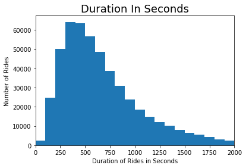

```python
#Visualizing the data in a histogram
duration_bins = np.arange(0, fordgobike_2017['duration_sec'].max() + 100, 100)
plt.hist(data = fordgobike_2017, x = 'duration_sec', bins = duration_bins);

plt.xlim(0, 2000);
plt.title('Duration In Seconds', fontsize = 18);
plt.xlabel('Duration of Rides in Seconds');
plt.ylabel('Number of Rides');
```

#### Monthly bike ride counts

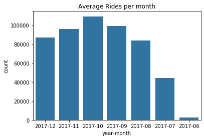

```python
# This slide indicates the data points in a month-wise fashion
sb.countplot(data=fordgobike_2017,x='year-month', color=sb.color_palette()[0])
plt.title('Average Rides per month');
```

#### bike trip by Subscriber and customer

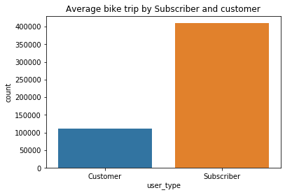

```python
sb.countplot(data=fordgobike_2017,x='user_type')
plt.title('Average bike trip by Subscriber and customer');
```

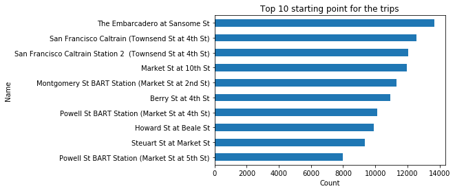

```python
top_names = fordgobike_2017.start_station_name.value_counts()[1:11].sort_values()
df_color = sb.color_palette()[0]
top_names.plot(kind = 'barh', color=df_color)
plt.title('Top 10 starting point for the trips')
plt.xlabel('Count')
plt.ylabel('Name');
```

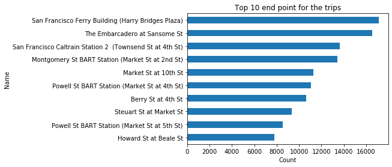

```python
top_names = fordgobike_2017.end_station_name.value_counts()[1:11].sort_values()
top_names.plot(kind = 'barh', color=df_color)
plt.title('Top 10 end point for the trips')
plt.xlabel('Count')
plt.ylabel('Name');
```

### Discuss the distribution(s) of your variable(s) of interest. Were there any unusual points? Did you need to perform any transformations?

I did not have to perform any transformation.

### Of the features you investigated, were there any unusual distributions? Did you perform any operations on the data to tidy, adjust, or change the form of the data? If so, why did you do this?

Yes I had to tidy the data as well as perform some operations I did some data erangling on the start_time and to extract Month and Year . From there I etracted the month and year for the trip data. This was done as I wanted to understand the influence of factors like month on the duration that the bike is ridden

## Bivariate Exploration

### Understanding the relation between the various variables

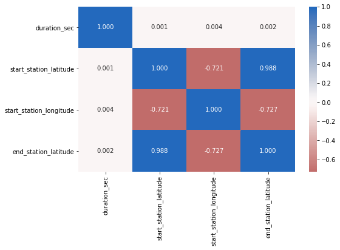

```python
numeric_vars = ['duration_sec','start_station_latitude','start_station_longitude','end_station_latitude']
plt.figure(figsize = [8, 5])
sb.heatmap(fordgobike_2017[numeric_vars].corr(), annot = True, fmt = '.3f',cmap = 'vlag_r', center = 0)
plt.show()
```

#### Observation :

[figure not shown]

```python
sb.catplot(x="user_type", y="duration_sec", data=fordgobike_2017)
plt.xlabel('Trip Duration')
plt.ylabel('user_type');
```

#### Observation :

in this chart we see the (Subscribers) often finish the race faster than the (Customers)

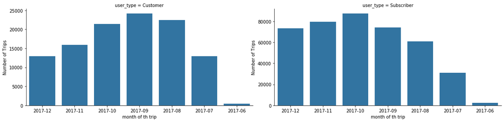

```python
F = sb.FacetGrid(data=fordgobike_2017,col='user_type', col_wrap = 2, height = 4, aspect=2, sharey=False)
F.map(sb.countplot, 'year-month')
for i in range(2):
    F.axes[i].set_xlabel('month of th trip')
    F.axes[i].set_ylabel('Number of Trips')
```

#### Observation :

We noticed that the subscribers has the most number of trips on October and on the other side where the customers has the most number of trips in September

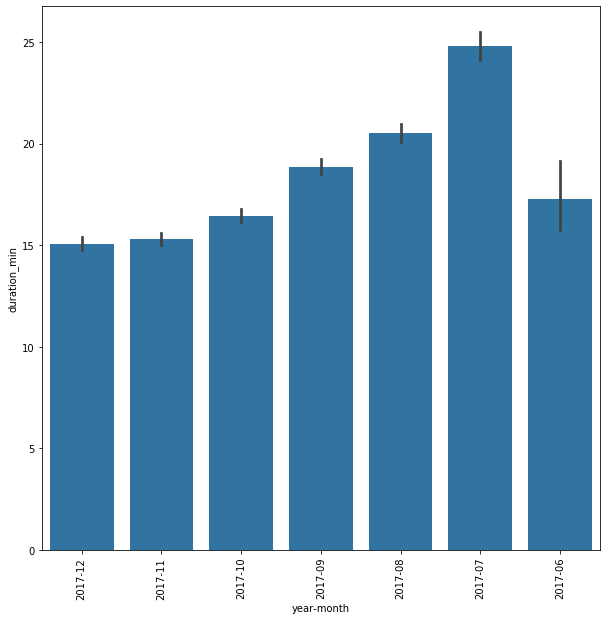

```python
fordgobike_2017['duration_min'] = fordgobike_2017['duration_sec'] // 60
plt.figure(figsize = [10, 10])
sb.barplot(data = fordgobike_2017, x = 'year-month', y = 'duration_min' , color= df_color)
plt.xticks(rotation=90)
plt.show()
```

#### Observation :

In this graph we can see that july has the most time spent in seconds which is 1500 seconds on average

### Did you observe any interesting relationships between the other features (not the main feature(s) of interest)?

We noticed that the subscribers has the most number of trips on October and on the other side where the customers has the most number of trips in September

## Multivariate Exploration

Finally, let's wrap up this notebook with a couple of multivariate explorations.

[figure not shown]

```python
fig = plt.figure(figsize = [8,6])
sb.pointplot(data = fordgobike_2017, x = 'year-month' , y = 'duration_min' , hue = 'user_type', palette = 'Reds', ci=None)
plt.title('Trip duartion across user type in different months')
plt.ylabel('Mean Trip Dduration (sec)')
plt.xlabel('Months')
plt.show();
```

### Talk about some of the relationships you observed in this part of the investigation. Were there features that strengthened each other in terms of looking at your feature(s) of interest?

Trip Duration in diffrent months taking into account the user type, now we can see the Customer has much higher trip duration in average.